# Environmental variation associated with topography explains butterfly diversity along a tropical elevation gradient - Cómbita - - Biotropica - Wiley Online Library

[Biotropica](https://onlinelibrary.wiley.com/journal/17447429)

[Early View](https://onlinelibrary.wiley.com/toc/17447429/0/0)

ORIGINAL ARTICLE

Free Access

# Environmental variation associated with topography explains butterfly diversity along a tropical elevation gradient

[José Luís Cómbita](https://onlinelibrary.wiley.com/action/doSearch?ContribAuthorRaw=C%C3%B3mbita%2C+Jos%C3%A9+Lu%C3%ADs),

[Carlos E. Giraldo](https://onlinelibrary.wiley.com/action/doSearch?ContribAuthorRaw=Giraldo%2C+Carlos+E),

[Federico Escobar](https://onlinelibrary.wiley.com/action/doSearch?ContribAuthorRaw=Escobar%2C+Federico),

First published: 23 November 2021

https://doi.org/10.1111/btp.13040

**Associate Editor::** Jennifer Powers

**Handling Editor::** Xavier Arnan

## Abstract

Few studies have evaluated the role of topography on the diversity patterns of biological communities along elevation gradients. We evaluated the influence of microclimate and vegetation structure associated with topographic variation on the richness and composition of species of different families of butterflies on a mountain located in a dry enclave (Chicamocha River Canyon) in the northern Andes, Colombia. We captured butterflies over four months at 18 elevations (300 to 1500 m a.s.l.) in two topographic positions (riverbed and hillslope) using an entomological net and traps baited with fermented fruit. In general, butterfly richness increased with elevation in both topographic positions. However, the richness–elevation relationship changed with butterfly family. The riverbed and hillslope sites host different assemblages of butterflies, and this pattern that was consistent for most families. In the riverbed, two sets of species are recognized along the elevation gradient (one below 700 m a.s.l. and the other above 1000 m a.s.l.), mainly owing to species replacement. On the hillslopes, there was no clear pattern of grouping associated with elevation. Microclimate differences between the riverbed and hillslope sites along the elevation gradient were related to the vegetation structure and explained the variation in butterfly species composition. Our results highlight the role of topography not only by explaining the response of species richness and composition to environmental variation determined by elevation, but also as a factor that must be considered in the planning and management of biodiversity conservation in the mountains.

Abstract in Spanish is available with online material.

## 1 INTRODUCTION

In their explorations of the mountains of the equinoctial regions of America, Humboldt and Bonpland (1807) recognized the role of elevation, topography, and climate on the distribution of plants and animals. The topography of the mountains plays a primary role in the regulation of their climate, soil type, primary productivity, and vegetation structure (Antonelli et al., 2018; Badgley et al., 2017), but the processes underlying this association are not well understood (Perrigo et al., 2020). Although the influence of topography on the distribution of species at different spatial scales has been recognized for many taxa of plants, birds, mammals, and insects (Binz et al., 2015; Kerr & Packer, 1997; Méndez-Toribio et al., 2016; Moeslund et al., 2013; Quintero & Jetz, 2018; Vasconcelos et al., 2003), few studies have addressed its role along elevation gradients to explain the diversity patterns of the communities that inhabit the mountains (Antonelli et al., 2018; Badgley et al., 2017; Perrigo et al., 2020).

Despite the fact that they account for less than 15% of the surface of the Earth, mountains host a third of the planet's biodiversity (Myers et al., 2000; Rahbek et al., 2019). One of the mountain regions most emblematic for its high diversity and levels of endemism is the tropical Andes (Van der Hammen, 2000). It has been suggested that the geological and paleoclimatic history of the Andes, as well as current variations in climate, the elevational stratification of the vegetation and topographic complexity (i.e., steep slopes and valleys of small streams and main rivers that vary in depth), have promoted the diversification and maintenance of a great number of plant and animal lineages with a clear taxonomic substitution of the communities with increasing elevation (Graham, 2009; Hazzi et al., 2018; Hughes & Eastwood, 2006; Rahbek et al., 2019).

Of the nearly 9000 butterfly species known in the Neotropics (Raven et al., 2020), at least 40% occur in the Andes (Pyrcz et al., 2014). Several studies show that butterfly richness decreases with elevation, while others report peaks of richness at intermediate elevations, though we also know that the richness–elevation relationship pattern changes depending on the family of butterflies studied (Acharya & Vijayan, 2015; Hawkins & DeVries, 1996; Janzen et al., 1976; Maicher et al., 2020; Peters et al., 2016; Pyrcz et al., 2014). As in other taxonomic groups, variation in butterfly diversity with increased elevation is related to reduced area and environmental complexity, the greater severity of climate conditions, a reduction in available resources and primary productivity (Hodkinson, 2005; Huston, 1994), and the degree of conservation of the habitats (Molina-Martínez et al., 2016). However, it is known that the magnitude of the effects of these factors also depends on the geological history and topographic complexity of the mountains (Lomolino, 2001; Rahbek et al., 2019; Sanders & Rahbek, 2012).

In the mountains, butterfly communities are comprised of species with narrow elevation ranges, associated with certain lineages of plants on which they depend for food and reproduction (Acharya & Vijayan, 2015; Pyrcz et al., 2009, 2014). Although the factors that determine the diversity of butterfly communities can vary among mountains (Stefanescu et al., 2011), the specific response to environmental variation is closely linked to the life-history traits of the species, such as their capacity for dispersal, diet and life cycle, habitat preference, and thermal tolerance (Cerrato et al., 2019; Habel et al., 2016; Prieto & Dahners, 2006). In this study, we examined the influence of topographic position (riverbed and hillslope) and elevation on the patterns of richness and composition in species of diurnal butterflies (Lepidoptera: Papilionoidea) found on a mountain located in a dry enclave in the northern Andes, Colombia. We addressed the following questions: (a) how does butterfly richness vary when we take into account the microclimate and vegetation structure changes associated with topographic position at different elevations, and do these patterns vary with family? and (b) what is the beta-diversity pattern and its relationship to the environmental conditions associated with topographic position and elevation? Based on our results, we discuss the patterns in the richness–elevation relationship and species composition by butterfly family in response to environmental variations determined by topography.

## 2 METHODS

### 2.1 Study area

The study was conducted at Mesa de Los Santos (6°45′ N, 73°06′ W), which is a large plateau (~430 km<sup>2</sup>) located in the canyon of the Chicamocha River and is considered the most extensive inter-Andean dry enclave in the Cordillera Oriental, Colombia (Fajardo-Gutiérrez et al., 2015; Pizano & García, 2014) (Figure 1). This canyon is the result of the erosion of the fluvial bed dating back to the early Oligocene (33.9 to 23.03 Ma), with the formation of large ravines on both sides, complex topography with deep, abrupt canyons (maximum depth of 2000 m) that cut through crystalline and sedimentary rock, and are often devoid of vegetation (Guzmán, 2016).

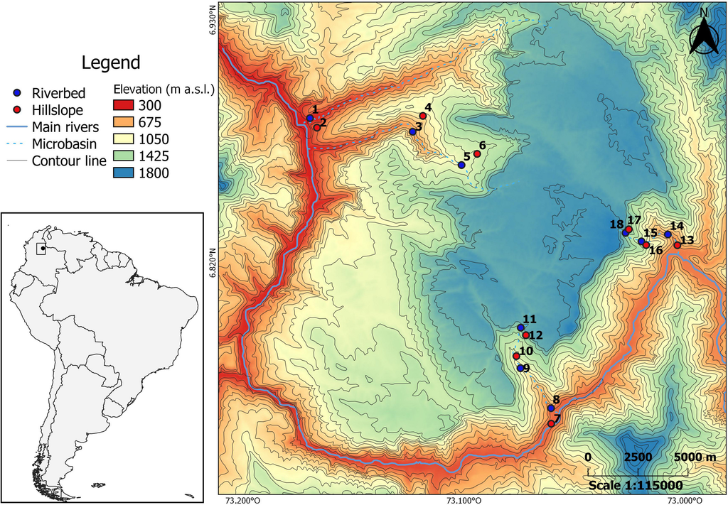

**FIGURE 1**

Location of the study area and the 18 sampling stations (SS) in each of the three microbasins on the Mesa de Los Santos mountain, northern Andes, Colombia. The elevation of each SS is given in Table 1

The region has a mean annual temperature of 24°C. Precipitation is markedly seasonal and less than 900 mm per year, falling mainly from April to May and August to September (Guzmán, 2016; Valencia-Duarte et al., 2012). The vegetation is tropical dry forest, with a great variety of plant cover types—from xerophytic scrub to areas with trees that are 20 m tall—that change in their structure and composition depending on soil type, the slope and proximity to bodies of water (Espinal, 1977; Guzmán, 2016; Holdridge, 1967). According to Camargo-Ponce de León and Agudelo (2017), the Chicamocha River Canyon has had a human presence since pre-Hispanic times and the greatest transformation occurred during the early 20<sup>th</sup> century. In Mesa de Los Santos, the deepest part of the canyon next to the riverbed is dominated by large trees of *Brosimum alicastrum* (Moraceae), *Anacardium excelsum* (Anacardiaceae), *Annona squamosa* (Annonaceae), *Ruprechtia ramiflora* (Polygonaceae), and *Tabernaemontana grandiflora* (Apocynaceae). It is also possible to find some non-native fruit species such as *Syzygium jambos* (Myrtaceae). The adjacent hillslopes are dominated by subxerophytic scrub with the presence of cacti and scattered trees of *Myrsine guianensis* (Fabaceae), *Prosopis juliflora* (Fabaceae), *Varronia curassavica* (Boraginaceae), and *Duranta mutisii* and *Lippia origanoides* (Verbenaceae) (Camargo-Ponce de León & Agudelo, 2017; Collazos-González & Echeverry-Galvis, 2017).

### 2.2 Study design

Sampling was conducted in 2014 during the dry season between the end of the first rainy period (May) and the beginning of the second rainy period (August) in three microbasins located at least 10 km apart. This period represents the predominant climate throughout the year on Mesa de Los Santos. In each microbasin, six elevations between 330 and 1540 m a.s.l. were selected and, at each elevation, one site was located at the bottom of a riverbed and one site on the neighboring hillslope (Figure 1, Table 1). At each site (or sampling station; hereafter SS), two transects, 200 m in length were established 50 m apart, for a total of 36 transects. The SS were selected based on accessibility, preserved native vegetation, because they were representative of each topographic position, and located away from urban and agricultural areas.

TABLE 1. Microclimate, plant richness, and vegetation structure from 100 m<sup>2</sup> plots at each sampling station (SS) according to topographic position (TP)

| **SS (TP)** | **Elevation (m a.s.l.)** | **Microclimate** *T*<sub>max</sub> (°C) | **Microclimate** *T*<sub>min</sub> (°C) | **Microclimate** **Rh (%)** | **Plant richness and vegetation structure** **PR** | **Plant richness and vegetation structure** **VH (m)** | **Plant richness and vegetation structure** **∑VC (m<sup>2</sup>)** | **Plant richness and vegetation structure** **∑BA (m<sup>2</sup>)** | **Abundance, Richness and *Ĉm*** **Ind**. | **Abundance, Richness and *Ĉm*** **S ± 95IC** | **Abundance, Richness and *Ĉm*** *Ĉm* ± 95IC |
| --- | --- | --- | --- | --- | --- | --- | --- | --- | --- | --- | --- |
| 1 (RB) | 329 | 35.5 | 27.6 | 65.1 | 16 | 15 | 721 | 4.2 | 264 | 51 ± 5 | 0.92 ± 0.02 |
| 2 (HS) | 491 | 36.7 | 29.8 | 59.5 | 11 | 7.5 | 201 | 0.8 | 88 | 16 ± 3 | 0.94 ± 0.04 |
| 3 (RB) | 678 | 34.9 | 25.3 | 58.6 | 15 | 16 | 405 | 3.8 | 265 | 74 ± 7 | 0.89 ± 0.03 |
| 4 (HS) | 930 | 36.1 | 23.3 | 61.8 | 19 | 9 | 153 | 0.6 | 264 | 45 ± 5 | 0.93 ± 0.02 |
| 5 (RB) | 1124 | 32.4 | 22.9 | 68.2 | 27 | 20 | 636 | 2.6 | 166 | 74 ± 8 | 0.73 ± 0.07 |
| 6 (HS) | 1220 | 35.9 | 21.2 | 62.1 | 25 | 11 | 337 | 0.7 | 159 | 68 ± 8 | 0.78 ± 0.06 |
| 7 (HS) | 485 | 35.4 | 27.6 | 61.2 | 16 | 7 | 170 | 1.0 | 143 | 31 ± 6 | 0.89 ± 0.04 |
| 8 (RB) | 522 | 36.2 | 30.4 | 58.8 | 10 | 10 | 418 | 1.2 | 194 | 42 ± 6 | 0.89 ± 0.03 |
| 9 (RB) | 1084 | 32.5 | 25.9 | 68.1 | 37 | 18 | 521 | 2.4 | 172 | 69 ± 8 | 0.76 ± 0.05 |
| 10 (HS) | 1104 | 35.4 | 27.4 | 57.7 | 23 | 10 | 245 | 0.6 | 206 | 80 ± 8 | 0.78 ± 0.05 |
| 11 (RB) | 1385 | 31.3 | 25.0 | 63.6 | 34 | 17 | 426 | 1.2 | 216 | 62 ± 7 | 0.88 ± 0.04 |
| 12 (HS) | 1472 | 33.7 | 24.1 | 65.8 | 23 | 9 | 72 | 0.2 | 114 | 30 ± 5 | 0.87 ± 0.05 |
| 13 (HS) | 594 | 38.9 | 26.2 | 61.3 | 11 | 5.6 | 178 | 0.5 | 77 | 17 ± 4 | 0.92 ± 0.05 |
| 14 (RB) | 699 | 36.0 | 26.8 | 61.7 | 24 | 7.6 | 281 | 1.1 | 115 | 45 ± 5 | 0.84 ± 0.06 |
| 15 (RB) | 1127 | 36.4 | 27.5 | 59.2 | 44 | 16 | 487 | 2.8 | 203 | 50 ± 9 | 0.87 ± 0.05 |
| 16 (HS) | 1161 | 36.2 | 27.5 | 51.0 | 30 | 6 | 146 | 0.5 | 203 | 39 ± 6 | 0.90 ± 0.03 |
| 17 (HS) | 1531 | 33.9 | 25.7 | 60.9 | 31 | 8 | 246 | 0.6 | 186 | 61 ± 7 | 0.82 ± 0.03 |
| 18 (RB) | 1539 | 30.8 | 21.3 | 70.2 | 30 | 12 | 437 | 1.5 | 200 | 59 ± 8 | 0.85 ± 0.05 |

### Note

- RB = riverbed, HS = hillslope, E = Elevation, T<sub>min</sub> = Minimum temperature, T<sub>max</sub> = Maximum temperature, Rh = Relative humidity, PR = Plant richness, VH = maximum height, ∑VC = Sum of the plant cover, ∑BA =Sum of the Basal area / m<sup>2</sup>. Also shown are the number of individuals (Ind.), butterfly species richness (S), and sample coverage (*Ĉm*) per SS. Sampling effort was equal for all of the SS: Entomological net (16 h), van Someren-Rydon trap (36 h). The total area sampled for plant richness and vegetation structure was 1800 m<sup>2</sup>.

### 2.3 Microclimate and vegetation structure

At each SS, maximum and minimum temperature (°C) and relative humidity (%) were measured every 30 min with a Brunton ADC<sup>®</sup> data logger during the sampling period (Table 1). To determine vegetation structure and plant richness, a 20 × 5 m (100 m<sup>2</sup>) plot was set up in each SS. All plants greater than 1 m in height (regardless of DBH) in each plot were identified to the finest level of classification possible and the following variables were recorded: cover (m<sup>2</sup>), height (m), and basal area (m<sup>2</sup>) (Table 1).

### 2.4 Data analysis

All analyses were performed in R v 4.0.2 (R Core Team, 2020).

#### 2.4.1 Species richness

We evaluated inventory completeness for the butterflies in each SS and for each of the families using sample coverage (*Ĉm*) as proposed by Chao and Jost (2012). Sample coverage (*Ĉm*) indicates the proportion of the total community represented by the species captured (Chao & Jost, 2012). When *Ĉm* ≈ 100%, the sample is considered complete with respect to the capture effort and technique utilized (Chao & Jost, 2012). For this calculation, we used the package *iNEXT* (Chao et al., 2014; Hsieh et al., 2016).

To evaluate the relationship between species richness (total and per family, except for Papilionidae) and elevation and topographic position (riverbed or hillslope), an analysis of covariance was used with elevation as the covariable, from a generalized linear model with negative binomial distribution of errors (GLM-nb) (link function = Log; Crawley, 2012), due to the overdispersion generated when a Poisson error distribution was used. Because of the proximity of the transects (~50 m) in each topographic position, for the analysis we used the cumulative species richness of the two transects. In all cases, models with and without the interaction between elevation and topographic position were fitted. The models fitted were log(μ) = β<sub>1</sub> + β<sub>2</sub> x elevation + β<sub>3</sub> × topographic position + ε, and when considering the interaction log(μ) = β<sub>1</sub> + β<sub>2</sub> × elevation * β<sub>3</sub> × topographic position + ε. For this, we used the *glm*.*nb* function (MASS) (Venables & Ripley, 2002). To select the best models, we compared the saturated model (with interaction) and the simplest model (no interaction) using an ANOVA (likelihood ratio tests of negative binomial GLMs) with the function *anova*.*negbin*, available in MASS (Venables & Ripley, 2002). The models were checked for plausibility by examining the standardized residuals as well as the graphic distribution of the errors (Crawley, 2012).

#### 2.4.2 Species composition

We evaluated changes in species composition using two approaches. First, we calculated the partitioned total beta-diversity (β<sub>CC</sub>) based on the Jaccard index into two additive components to determine the contribution of species replacement or spatial differentiation (β<sub>REPL</sub>), and differences in species richness (β<sub>RICH</sub>) using the function *beta*.*multi* (BAT) (Cardoso et al., 2015; Carvalho et al., 2012). Subsequently, we used non-metric multidimensional scaling (NMDS) based on the Bray–Curtis index to define the overall differences in species composition among SS and determine the relationship between the ordination and microclimate and vegetation structure (continuous variables) as a function of topographic position (categorical variable) (Table 1) using *metaMDS* and *envfit* in the *vegan* package (Oksanen et al., 2019). The projection of the continuous variables in the space of ordination indicates the direction in which the linear change in a given variable occurs most rapidly and the maximum correlation with the configuration of the ordination, while the categorical variable represents the average of the ordination scores for each topographic position (Oksanen et al., 2019). The significance of the fitted variables was evaluated using 999 permutations (Oksanen et al., 2019).

## 3 RESULTS

### 3.1 Species richness

In both topographic positions, the richness of all of the butterflies (Papilionoidea) increased with elevation (GLM-nb, *z* = 2.6, *p* = <.01, Figure 2a). This pattern was maintained on examination of the richness–elevation relationship in each family (Figure 2b–f). However, for the riverbed sites, the richness pattern differed with family: in Nymphalidae and Riodinidae, richness tended to increase with elevation, while in Hesperiidae, Lycaenidae, and Pieridae, the number of species decreased with elevation (Figure 2b–f), though the richness–elevation relationship was only significant for Nymphalidae (GLM-nb, *z* = 3.4, *p* = <.001) and Pieridae (GLM-nb, *z* = −2.25, *p* = <.05) (Figure 2b,f), and the interaction was only significant for Pieridae (Table S3).

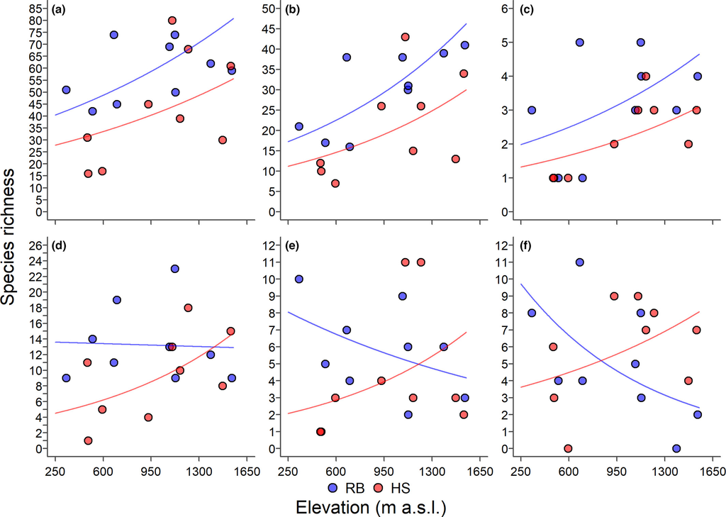

**FIGURE 2**

Species richness of all of the butterflies (Papilionoidea, a) and by family. Nymphalidae (b), Riodinidae (c), Hesperiidae (d), Lycaenidae (e), and Pieridae (f) as a function of elevation and topographic position. The lines indicate the mean of the values fitted from the negative binomial model for each one of the topographic positions (RB = riverbed, HS = hillslope)

The total number of butterfly species was more variable for the hillslope sites (range: 16 to 80 species) than for the riverbed sites (range: 42 to 74 species) (Table 1). A comparison of the medians showed that the richness of all species was greater in riverbed than in hillslope sites (GLM-nb, *χ*<sup>2</sup> = 5.6, *df* =1, *p* = <.05, Figure 3a). However, the magnitude of the differences in richness between topographic positions changed when analyzed by family (Figure 3b–f), except in Pieridae, for which richness was greater in hillslope than in riverbed sites (Figure 3f). In the other families, richness was greater in riverbed than in hillslope sites (Figure 3a–e). The difference in species richness between topographic positions was only significant for Nymphalidae (GLM-nb, *χ*<sup>2</sup> = 6.7, *df* =1, *p* = <.01) and Hesperiidae (GLM-nb, *χ*<sup>2</sup> = 3.9, *df* =1, *p* = <.05) (Figure 3b,d; Table S3).

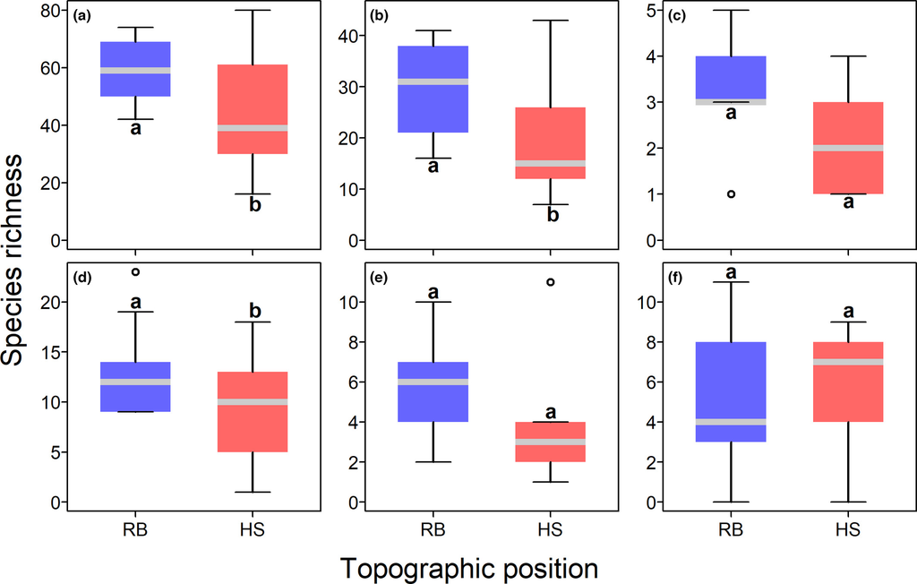

**FIGURE 3**

Box-plot comparing the median of the species richness in each topographic position (RB =riverbed, HS =hillslope) for all of the butterflies (Papilionoidea, a) and for each of the families: Nymphalidae (b), Riodinidae (c), Hesperiidae (d), Lycaenidae (e), and Pieridae (f). The lower and upper bars of the boxes represent the first (q1) and third (q3) quartiles, respectively. The horizontal line within each box corresponds to the median. The upper error bar represents q3 + 1.5(q3–q1) and the lower error bar represents q1–1.5(q3–q1). Circles denote atypical values. Different letters associated with the bars of the boxes indicate significant differences (Table S2: ANOVA GLM-nb, *p* <.05)

### 3.2 Species composition

Total beta-diversity (β<sub>CC</sub>) was 0.80 (variance ±0.002) with the greatest contribution made by species replacement (β<sub>REPL</sub> = 0.52 ± 0.001) and, to a lesser extent, by the dissimilarity due to the difference in species richness (β<sub>RICH</sub> = 0.28 ± 0.001). For the total beta-diversity in the riverbed sites (β<sub>CC</sub> = 0.80 ± 0.0005) the contribution of replacement (β<sub>REPL</sub> = 0.65 ± 0.001) was greater, while that of the difference in species richness was lower (β<sub>RICH</sub> = 0.15 ± 0.0001). In hillslope sites, the contributions made by replacement (β<sub>REPL</sub> = 0.42 ± 0.001) and richness differences (β<sub>RICH</sub> = 0.37 ± 0.001) to the total beta-diversity (β<sub>CC</sub> = 0.79 ± 0.001) were similar.

Close to 98% of the variation in the NMDS ordination of the SS was explained by the first two axes (Stress = 0.12). The NMDS separated the SS according to topographic position and, throughout NMDS1 there was an evident ordination of the SS located in riverbed with elevation gradient that discriminated two groups: one below 700 m a.s.l. and the other above 1000 m a.s.l. For the hillslope sites, a mixture of SS was observed that did not correspond to the change in elevation (Figure 4a). With the exception of relative humidity, all of the microclimate and vegetation structure variables along with topographic position significantly explained the changes in butterfly species composition (Figure 4a,b). Elevation and maximum temperature produced the best fit with the ordination of the SS compared to the other variables (Figure 4a,b).

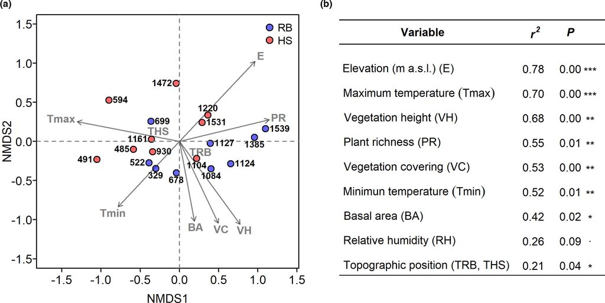

**FIGURE 4**

(a) NMDS ordination based on of the total set of SS using species abundance data together with the significant fit (*envfit*, *p* <.05) of microclimate and vegetation structure by elevation and topographic position (abbreviations Table 1 and Figure 4b). (b) Goodness of fit (*r*<sup>2</sup>) and significance values (*P*) for each of the fitted variables. The significance value was determined by a permutation procedure (999 permutations). Significant values: *** = *p* <.001; ** = *p* <.01; * = *p* <.05

## 4 DISCUSSION

The richness–elevation relationship has received considerable attention in recent decades with studies focusing on several taxonomic groups (Cirimwami et al., 2019; Joaqui et al., 2021; McCain, 2005; Peters et al., 2016; Rahbek, 1995). The main conclusion has been that there is no general pattern along elevation gradients, though some patterns are commonly detected (monotonic decrease and unimodal hump-shaped). Our findings are contrary to the general pattern found for many mountains, which report a decrease in species richness with increasing elevation (Rahbek, 1995; Sanders & Rahbek, 2012). Recent studies suggest that the influence of ecological factors such as climate, soil type, primary productivity, and resource availability that explain diversity patterns in elevation gradients, in turn depends on the area, shape, and topography of the mountains (Badgley et al., 2017; Perrigo et al., 2020; Quintero & Jetz, 2018; Rahbek et al., 2019).

Some studies indicate that the patterns of diversity along elevation gradients depend on the evolutionary and biogeographic history of the species that make up the communities, conditioning their ecological response to environmental gradients (Joaqui et al., 2021; Machac et al., 2010; Peters et al., 2016). Thus, depending on the species’ life-history traits that are related to thermal tolerance, dispersal ability, habitat preference, and feeding habit, topography can act as an ecological filter and explain the different patterns of richness observed for the different butterfly families. While the richness–elevation relationship was not statistically significant for all families, this pattern was observed for Nymphalidae and Riodinidae. In Hesperiidae, Lycaenidae, and Pieridae, however, the richness–elevation relationship varied with topographic position. In these three families, species richness in the riverbed sites tended to decrease with elevation, while in the hillslope sites it tended to increase. These differences among families could be related to behavioral traits such as hilltopping (Pe'er et al., 2013) in which, and in response to the topography, some insects (specially butterflies) fly toward the summits and/or slopes of the mountains in search of mates and complementary food resources (Alcock, 1987; Baughman & Murphy, 1988; Pe'er et al., 2013). While this behavior has been recorded for some species of different butterfly families, including Hesperiidae (Carneiro et al., 2014), Lycaenidae (Prieto & Dahners, 2006), and Pieridae (Shapiro, 1975, 1979), further behavioral studies are necessary to evaluate the contribution of hilltopping to the differences in butterfly richness with the topographic variation of the mountains. Future studies are necessary to evaluate the physiological and behavioral response of species to microclimate variation and changes in resource availability (e.g., floral phenology of butterfly host-plants) along elevation gradients.

In general, butterfly richness was greater in riverbed than on the hillslope sites, except for family Pieridae. This is the opposite of what Binz et al. (2015) found for fruit-feeding butterflies, and Rabl et al. (2020) for moths, in a topographically heterogeneous landscape in SW Costa Rica, where the diversity was greater on slopes and ridges compared to creeks. According to Courtney and Chew (1987), the structure of the butterfly community is determined by the degree of shade associated with habitat type and host plant community availability. The highest butterfly richness found in our riverbed sites could be explained by the presence of a greater diversity of plants, greater cover and complexity in the vegetation structure, which have less stressful microclimate conditions (i.e., less contrast between minimum and maximum temperatures throughout the day), as well as a greater availability of resources, that together contribute to fulfilling the specific habitat requirements of a greater number of butterfly species (Binz et al., 2015; Casas-Pinilla et al., 2017; Eilers et al., 2013; Humpden & Nathan, 2010; Murdoch et al., 1972; Zellweger et al., 2017).

Information on butterfly species’ preferences for host plants in our study area is limited, however, it is well known that host plants have played a crucial role in the evolution and structure of butterfly communities (Ehrlich & Raven, 1964; Ferrer-Paris et al., 2013; Vane-Wright, 1978). Specific butterfly–host plant relationships and the association of species with given vegetation types varies among butterfly families (Ferrer-Paris et al., 2013). Beyond the close association between hosts and larvae, it has been reported that the community of host plants itself is not a reliable predictor of the richness and occurrence of adult butterflies at the local and regional scales (Courtney & Chew, 1987; Hawkins & Porter, 2003). Contrary to our results, Hawkins and Porter (2003) found a weak association between plant richness and butterfly richness, on considering different climate factors and topography.

Various studies have revealed marked patterns of species turnover in butterfly communities with increasing elevation (Acharya & Vijayan, 2015; Beirão et al., 2020; Fleishman et al., 1998; Kocher & Williams, 2000; Maicher et al., 2020; Molina-Martínez et al., 2016; Pires et al., 2020; Pyrcz & Wojtusiak, 2002; Pyrcz et al., 2009; Wagner et al., 2013), as well as an effect of topography on butterfly composition (Binz et al., 2015; Fleishman & Nally, 2002). Due to the greater influence of species replacement on beta-diversity in riverbeds, we found that the butterfly community at this topographic position became segregated as elevation increased, with two sets of species: one associated with the low parts of the gradient and the other associated with the high parts. This could mean that the species of the lowlands, which are adapted to dry and arid conditions, are limited in terms of their ability to establish in the high and humid part of the mountain. In contrast, the butterfly community of the hillslope sites did not segregate with elevation and the grouping was determined by the similar contribution of both replacement and richness differences. This could indicate that, for the butterfly species capable of exploiting different habitats, elevation could be a less restrictive factor.

Our results also support the notion that variation in microclimate as it relates to vegetation structure associated with topographic position is a crucial predictor of beta-diversity. Of the 253 butterfly species collected, 130 (50%) are shared and the number of exclusive species was greater in riverbed (90 species, 36%) than in hillslope sites (33 species, 14%) (Table S1). This pattern was similar for the families Lycaenidae (shared: 43%, exclusive to riverbed: 38%, exclusive to hillslope: 20%), Hesperiidae (51%, 36%, 13%), Nymphalidae (57%, 35%, 8%), and Pieridae (62%, 24%, 14%). In contrast, the families Riodinidae and Papilionidae had opposite patterns: in Papilionidae, most of the species (80%) were shared between topographic positions, while in Riodinidae only 29% were shared, 46% were exclusive to the riverbed, and 25% to the hillslope sites. Our results suggest that to guarantee the effective conservation of the phylogenetic and functional diversity of the butterfly communities and likely that of other organisms in the mountains, it is necessary to take into account the environmental variation determined by the vegetation structure that is associated with topographic variation.

## 5 CONCLUSION

This study analyzed the complex interaction of topography and elevation in relation to the diversity of the butterfly community on a plateau-shaped mountain located in a dry enclave in the northern tropical Andes. In contrast to what has been observed in other studies, butterfly richness increased with elevation, which seems to be explained by the shape of the mountain and its regional climate context. However, for some butterfly families, the richness–elevation relationship changed with topographic position and, regardless of elevation the butterfly community was strongly influenced by microclimate and vegetation structure. Also of interest is the fact that the pattern of the composition of the butterfly community on the elevation gradient studied was different at each topographic position, with the riverbed and hillslope sites clearly hosting different sets of species. It seems that the differences in the response of the butterfly families to elevation according to topographic position could be related to particular ecophysiological and behavioral traits of the species. Thus, our results highlight the role of topography in local and regional conservation planning and in the management of species with different ecological requirements, where topographic variation is a key factor in mitigating the deleterious effects of increasing temperature. A topography-based approach can enhance long-term biodiversity conservation in the mountains, an ecosystem that, worldwide, is seriously threatened by climate change.

## ACKNOWLEDGMENTS

The field work of this study was funded by the project, “*Desarrollo y extensión de un modelo de corredor ecológico vertical de cañada para la conservación del bosque seco tropical y la adaptación al cambio climático en la Mesa de Xéridas*, *en el cinturón árido del bajo Chicamocha-Alto Sogamoso*” headed by the Fundación Guayacanal, Fundación Conserva and Fundación Chimbilako (Colombia). José Luis Cómbita thanks the Fundación Guayacanal for the loan of equipment and logistical support for carrying out the fieldwork of the study, and Jeisson Ardila for assistance with the fieldwork. Finally, we wish to thank the reviewers for their suggestions with respect to the manuscript.

## CONFLICT OF INTEREST

The authors declare no competing interests.

## AUTHORS’ CONTRIBUTIONS

JLC and CEG conceived the original idea, JLC collected the data; JLC, CEG, and FES conceived the idea for this article and ran the statistical analyses; JLC and FES wrote the first complete draft; all authors (JLC, CEG, FES) contributed to subsequent drafts, revisions, review comments, and gave final approval for publication.

[figure not shown]

[Early View](https://onlinelibrary.wiley.com/toc/17447429/2021/0/0)

Online Version of Record before inclusion in an issue

### Recommended

  [Biotropica](https://onlinelibrary.wiley.com/journal/17447429)

[back](https://onlinelibrary.wiley.com/doi/10.1111/btp.13040)